# *De novo* assembly of ddRAD loci with ipyrad

Mar Llabaria and José Ignacio Lucas Lledó

2025-03-06

## Parameters file

Demultiplexing was a difficult task, because of how disorganized the original data was. After demultiplexing, it was necessary to merge the individually demultiplexed projects and to branch out only the *Crepidostomum* samples (it turns out they were not alone). Here, my intention was to run clustering (step 3) and subsequent steps from the already filtered and trimmed reads of only *Crepidostomum* samples, present in `../2023-05-17/crepi_edits`. However, I realize that a reason for this not to work is that `ipyrad` will not run step 3 unless step 2 is already done. And I cannot tell `ipyrad` I did that in another folder, because `ipyrad` trusts the `crepi.json` file, which contains the whole history of the analysis.

Thus, if I am to run steps 3 on in a different folder from where steps 1 and 2 were run, I need to hack the `ipyrad.json` file, for which I need to bring some files here…

```bash
if [ ! -d crepi_edits ]; then
   # Hard links not allowed for directories
   mkdir crepi_edits
fi
for f in $(ls -1 /nata/joiglu/crepidostomum2/results/2023-05-17/crepi_edits); do
   if [ ! -e crepi_edits/$f ]; then
      ln /nata/joiglu/crepidostomum2/results/2023-05-17/crepi_edits/$f crepi_edits/$f
   fi
done

if [ ! -e crepi.json ]; then
   JSON=/nata/joiglu/crepidostomum2/results/2023-05-17/crepi.json
   sed 's|/nata/joiglu/crepidostomum2/results/2023-05-17|../2023-05-17b|g' $JSON | \
   sed 's|Merged: PAR2no10, PAR2no11, PAR2no12, PAR2no13, PAR2no14, PAR2no15, PAR2no16, PAR2no1, PAR2no2, PAR2no3, PAR2no4, PAR2no5, PAR2no6, PAR2no7, PAR2no8, PAR2no9||g' \
   > crepi.json
fi

if [ ! -e ipopmap.txt ]; then
   cp ../2023-05-17/ipopmap.txt ./
fi

if [ ! -e params-crepi.txt ]; then
   PARAMS=/nata/joiglu/crepidostomum2/results/2023-05-17/params-crepi.txt
   sed 's|/nata/joiglu/crepidostomum2/results/2023-05-17|../2023-05-17b|g' $PARAMS | \
   sed 's|Merged: PAR2no10, PAR2no11, PAR2no12, PAR2no13, PAR2no14, PAR2no15, PAR2no16, PAR2no1, PAR2no2, PAR2no3, PAR2no4, PAR2no5, PAR2no6, PAR2no7, PAR2no8, PAR2no9||g' \
   > params-crepi.txt
fi

IPYRAD=/opt/miniconda3/envs/ipyrad/bin/ipyrad
for i in 85 90 92 94 96 98; do
   if [ ! -e params-crepi$i.txt ]; then
      $IPYRAD -p params-crepi.txt -b crepi$i
      sed -i "/## \[5\]/c denovo          ## [5] [assembly_method]"         params-crepi$i.txt
      sed -i "/## \[14\]/c 0.$i           ## [14] [clust_threshold]"        params-crepi$i.txt
   fi
done
```

The successful branching above suggests that I convinced `ipyrad` to use the edits from the previous *crepi* run here in this new folder. I only had to update the paths. And I erased the information of the previous merging. Unfortunately, this is not portable, and I had to transfer all `json` and `params` files to Garnatxa and edit them there again. I am not keeping copies of those files, but I will save here the submission files at least.

## Step 3: within sample clustering

Running `ipyrad` from within an Rmarkdown document is not easy, because `bash` blocks start a `bash` session in a new environment, not in the same conda environment where we may be executing the Rmarkdown document. In addition, I plan to run `ipyrad` in Garnatxa. Actually, the submission scripts must be saved here. Below I transcribe the commands as if they were run here, but they are not.

```bash
for i in 85 90 92 94 96 98; do
   if [ ! -e clustering0.$i.log ]; then
      ipyrad -p params-crepi$i.txt -f -s 3 -c 6 1> clustering0.$i.log 2> clustering0.$i.err &
   fi
done
wait
```

The six processes shown above run for 24 hours in Garnatxa, and most of them finished. Even incomplete runs are useful to compare the clustering efficiency among clustering thresholds. I only need the clusters from at least one sample to get an idea of how the number and size of clusters change with the threshold.

```bash
if [ ! -e summary_clustering.txt ]; then
   echo -e "Sample\tClustThres\tClustNum\tMeanSize" > summary_clustering.txt
   for s in N044Cx2 S004Cmb S023Cxc S027Cxa S117Cmb S125Cma S125Cmc; do
      for i in 85 90 92 94 96 98; do
         gawk -v SAMPLE=$s -v CLUST=$i '(/^\/\//){
            N += 0.5
            if (S > 0) F[S]++
            S = 0
         }(/^>/){
            split($1, A, /;/)
            split(A[2], B, /=/)
            S += B[2]
         }END{
            HISTOFILE = FILENAME
            gsub(/clust\.txt/, "histo.txt", HISTOFILE)
            N += 1
            F[S]++
            for (s in F) {
               SUMSIZE += F[s] * s
               SUMFREQ += F[s]
               print s "\t" F[s] >HISTOFILE
            }
            if (N != SUMFREQ) exit "Error counting?"
            print SAMPLE "\t" CLUST / 100 "\t" N "\t" SUMSIZE / SUMFREQ
         }' crepi${i}_clust_0.$(echo $i | sed 's/0$//')/$s.clust.txt >> summary_clustering.txt
      done
   done
fi
```

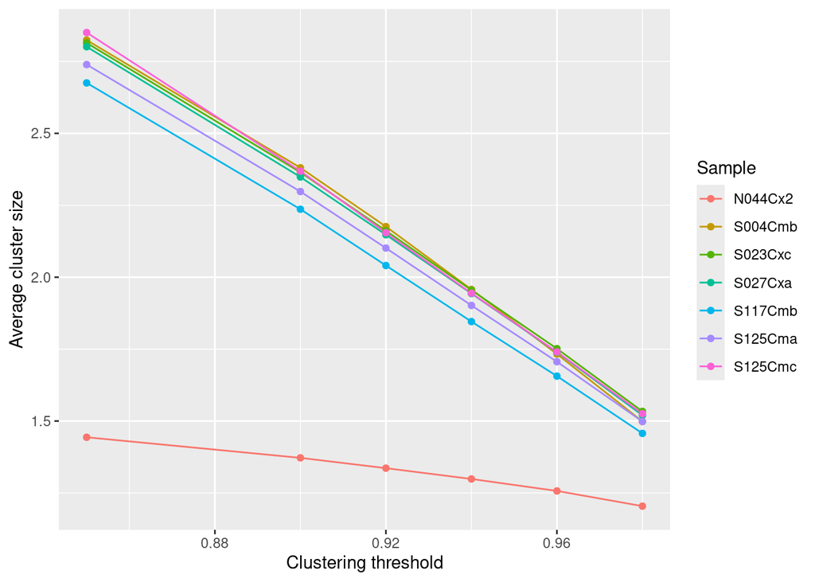

```r
library(ggplot2)
clusters <- read.table('summary_clustering.txt', header = TRUE)
ggplot(clusters, aes(x = ClustThres, y = MeanSize, color = Sample)) +
   geom_line() + geom_point() + xlab('Clustering threshold') +
   ylab('Average cluster size')
```

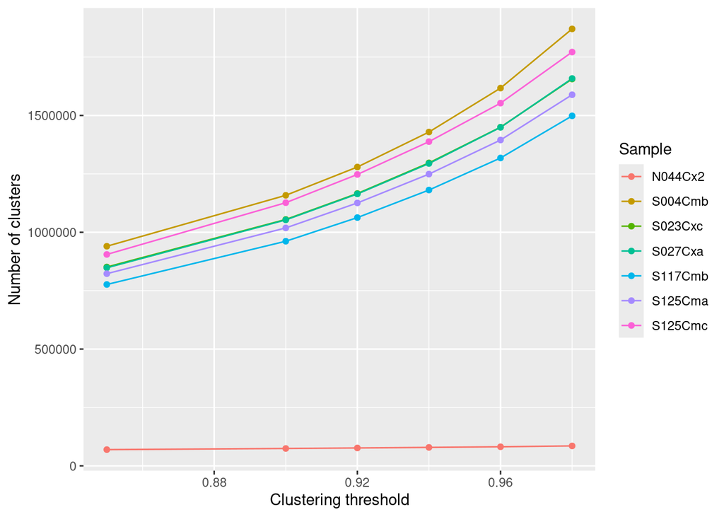

```r
ggplot(clusters, aes(x = ClustThres, y = ClustNum, color = Sample)) +
   geom_line() + geom_point() + xlab('Clustering threshold') +
   ylab('Number of clusters')
```

```r
library(MetBrewer)
N044Cx2 <- lapply(c(85, 90, 92, 94, 96, 98), function(x) {
   read.table(sprintf('crepi%i_clust_%s/N044Cx2.histo.txt', x, x/100),
              col.names = c('Size', 'Freq'))
})
S004Cmb <- lapply(c(85, 90, 92, 94, 96, 98), function(x) {
   read.table(sprintf('crepi%i_clust_%s/S004Cmb.histo.txt', x, x/100),
              col.names = c('Size', 'Freq'))
})
S023Cxc <- lapply(c(85, 90, 92, 94, 96, 98), function(x) {
   read.table(sprintf('crepi%i_clust_%s/S023Cxc.histo.txt', x, x/100),
              col.names = c('Size', 'Freq'))
})
S027Cxa <- lapply(c(85, 90, 92, 94, 96, 98), function(x) {
   read.table(sprintf('crepi%i_clust_%s/S027Cxa.histo.txt', x, x/100),
              col.names = c('Size', 'Freq'))
})
S117Cmb <- lapply(c(85, 90, 92, 94, 96, 98), function(x) {
   read.table(sprintf('crepi%i_clust_%s/S117Cmb.histo.txt', x, x/100),
              col.names = c('Size', 'Freq'))
})
S125Cma <- lapply(c(85, 90, 92, 94, 96, 98), function(x) {
   read.table(sprintf('crepi%i_clust_%s/S125Cma.histo.txt', x, x/100),
              col.names = c('Size', 'Freq'))
})
S125Cmc <- lapply(c(85, 90, 92, 94, 96, 98), function(x) {
   read.table(sprintf('crepi%i_clust_%s/S125Cmc.histo.txt', x, x/100),
              col.names = c('Size', 'Freq'))
})

# Order by decreasing cluster size and add cumulative sum
N044Cx2 <- lapply(N044Cx2, function(x) {
   z <- x[order(x$Size, decreasing = TRUE),]
   z$CumFreq <- cumsum(z$Freq)
   z$CumSum <- cumsum(z$Size * z$Freq)
   return(z)})
S004Cmb <- lapply(S004Cmb, function(x) {
   z <- x[order(x$Size, decreasing = TRUE),]
   z$CumFreq <- cumsum(z$Freq)
   z$CumSum <- cumsum(z$Size * z$Freq)
   return(z)})
S023Cxc <- lapply(S023Cxc, function(x) {
   z <- x[order(x$Size, decreasing = TRUE),]
   z$CumFreq <- cumsum(z$Freq)
   z$CumSum <- cumsum(z$Size * z$Freq)
   return(z)})
S027Cxa <- lapply(S027Cxa, function(x) {
   z <- x[order(x$Size, decreasing = TRUE),]
   z$CumFreq <- cumsum(z$Freq)
   z$CumSum <- cumsum(z$Size * z$Freq)
   return(z)})
S117Cmb <- lapply(S117Cmb, function(x) {
   z <- x[order(x$Size, decreasing = TRUE),]
   z$CumFreq <- cumsum(z$Freq)
   z$CumSum <- cumsum(z$Size * z$Freq)
   return(z)})
S125Cma <- lapply(S125Cma, function(x) {
   z <- x[order(x$Size, decreasing = TRUE),]
   z$CumFreq <- cumsum(z$Freq)
   z$CumSum <- cumsum(z$Size * z$Freq)
   return(z)})
S125Cmc <- lapply(S125Cmc, function(x) {
   z <- x[order(x$Size, decreasing = TRUE),]
   z$CumFreq <- cumsum(z$Freq)
   z$CumSum <- cumsum(z$Size * z$Freq)
   return(z)})

# N50
N044Cx2.N50 <- sapply(N044Cx2, function(x) {
   HalfNumReads <- max(x$CumSum) / 2
   k <- min(which(x$CumSum >= HalfNumReads))
   N50 <- x[k, 'Size']
   return(N50)
})
S004Cmb.N50 <- sapply(S004Cmb, function(x) {
   HalfNumReads <- max(x$CumSum) / 2
   k <- min(which(x$CumSum >= HalfNumReads))
   N50 <- x[k, 'Size']
   return(N50)
})
S023Cxc.N50 <- sapply(S023Cxc, function(x) {
   HalfNumReads <- max(x$CumSum) / 2
   k <- min(which(x$CumSum >= HalfNumReads))
   N50 <- x[k, 'Size']
   return(N50)
})
S027Cxa.N50 <- sapply(S027Cxa, function(x) {
   HalfNumReads <- max(x$CumSum) / 2
   k <- min(which(x$CumSum >= HalfNumReads))
   N50 <- x[k, 'Size']
   return(N50)
})
S117Cmb.N50 <- sapply(S117Cmb, function(x) {
   HalfNumReads <- max(x$CumSum) / 2
   k <- min(which(x$CumSum >= HalfNumReads))
   N50 <- x[k, 'Size']
   return(N50)
})
S125Cma.N50 <- sapply(S125Cma, function(x) {
   HalfNumReads <- max(x$CumSum) / 2
   k <- min(which(x$CumSum >= HalfNumReads))
   N50 <- x[k, 'Size']
   return(N50)
})
S125Cmc.N50 <- sapply(S125Cmc, function(x) {
   HalfNumReads <- max(x$CumSum) / 2
   k <- min(which(x$CumSum >= HalfNumReads))
   N50 <- x[k, 'Size']
   return(N50)
})

N50 <- data.frame(
   Sample = rep(c('N044Cx2', 'S004Cmb', 'S023Cxc', 'S027Cxa',
                  'S117Cmb', 'S125Cma', 'S125Cmc'), each = 6),
   ClustThres = rep(c(0.85, 0.90, 0.92, 0.94, 0.96, 0.98), 7),
   N50 = c(N044Cx2.N50, S004Cmb.N50, S023Cxc.N50, S027Cxa.N50,
           S117Cmb.N50, S125Cma.N50, S125Cmc.N50)
)
```

N50 is the size (in number of reads) of the smallest size of the set of largest clusters that contain half the total number of reads.

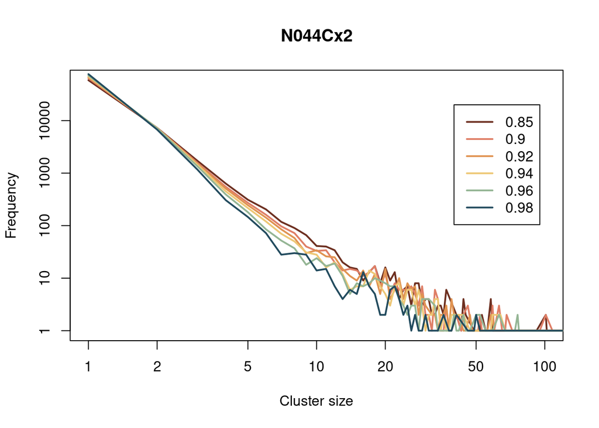

```r
paleta <- met.brewer('Hokusai1', 6)
plot(N044Cx2[[1]]$Size, N044Cx2[[1]]$Freq, type = 'l', col = paleta[1],
     xlab = 'Cluster size', ylab = 'Frequency', log = 'xy',
     main = 'N044Cx2', xlim = c(1, 100), lwd = 2)
lines(N044Cx2[[2]]$Size, N044Cx2[[2]]$Freq, col = paleta[2], lwd = 2)
lines(N044Cx2[[3]]$Size, N044Cx2[[3]]$Freq, col = paleta[3], lwd = 2)
lines(N044Cx2[[4]]$Size, N044Cx2[[4]]$Freq, col = paleta[4], lwd = 2)
lines(N044Cx2[[5]]$Size, N044Cx2[[5]]$Freq, col = paleta[5], lwd = 2)
lines(N044Cx2[[6]]$Size, N044Cx2[[6]]$Freq, col = paleta[6], lwd = 2)
legend(40, 20000, c(0.85, 0.90, 0.92, 0.94, 0.96, 0.98), col = paleta, lwd = 2)
```

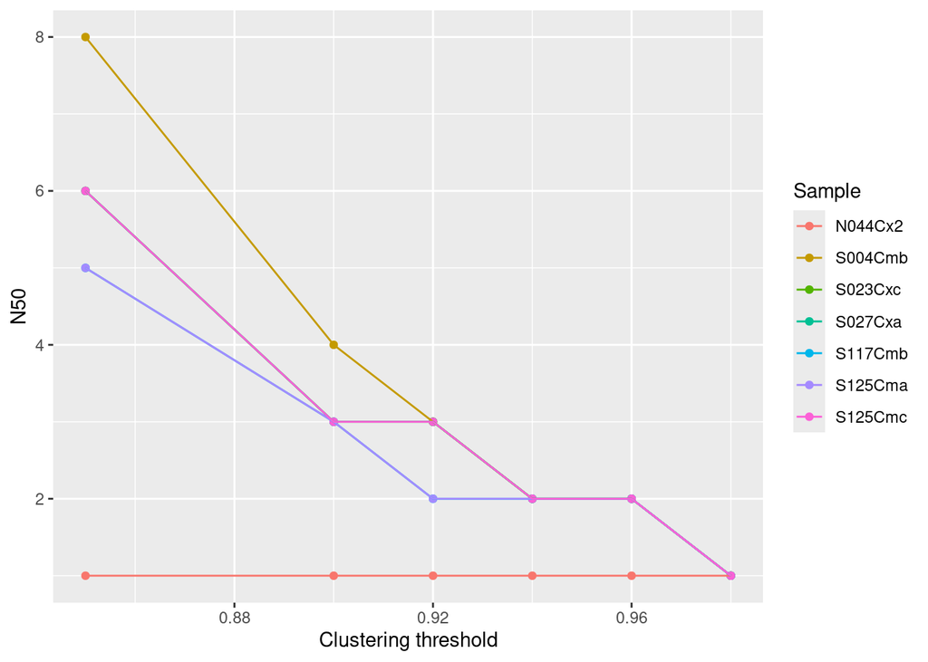

```r
ggplot(N50, aes(x = ClustThres, y = N50, color = Sample)) +
   geom_point() + geom_line() + xlab('Clustering threshold') +
   ylab('N50')
```

I expected a qualitative change in the way the number of clusters or their average or median size covary with clustering thresholds. However, there is no indication of any turning point, from which we could be merging paralogs or splitting alleles. The only sensitive decision is to keep running the analysis with more than one value and choose later. See McCartney-Melstad, Gidiş, and Shaffer (2019).

## The rest of the analysis

I run in Garnatxa de whole analysis with 5 different clustering thresholds: 0.94, 0.95, 0.96, 0.97 and 0.98. The scripts submitted there are saved in the `GarnatxaScripts` subfolder. Below I specify, but do not run, how I would do it here:

```bash
IPYRAD=/opt/miniconda3/envs/ipyrad/bin/ipyrad
for i in 94 95 96 97 98; do
   if [ ! -e crepi${i}_outfiles/crepi${i}.vcf ]; then
      if [ ! -e params-crepi$i.txt ]; then
         ipyrad -p params-crepi -b crepi$i
         sed -i "/## \[5\]/c denovo       ## [5] [assembly_method]"  params-crepi$i.txt
         sed -i "/## \[14\]/c 0.$i        ## [14] [clust_threshold]" params-crepi$i.txt
      fi
      $IPYRAD -p params-crepi$i.txt -f -s 34567 -c 6 1> crepi$i.log 2> crepi$i.err
   fi
done
```

```bash
if [ ! -e summary_loci_filters.txt ]; then
   echo -e "Threshold\tDuplicates\tIndels\tSNPs\tHetSites\tMinSamp\tPassing\tNumSNPs" > summary_loci_filters.txt
   for i in 94 95 96 97 98; do
      DUP=$(grep filtered_by_rm_duplicates  crepi${i}_outfiles/crepi${i}_stats.txt | gawk '{print $3}')
      IND=$(grep filtered_by_max_indels     crepi${i}_outfiles/crepi${i}_stats.txt | gawk '{print $3}')
      SNP=$(grep filtered_by_max_SNPs       crepi${i}_outfiles/crepi${i}_stats.txt | gawk '{print $3}')
      HET=$(grep filtered_by_max_shared_het crepi${i}_outfiles/crepi${i}_stats.txt | gawk '{print $3}')
      MIN=$(grep filtered_by_min_sample     crepi${i}_outfiles/crepi${i}_stats.txt | gawk '{print $3}')
      PAS=$(grep total_filtered_loci        crepi${i}_outfiles/crepi${i}_stats.txt | gawk '{print $4}')
      NUMSNP=$(grep -v "^#" crepi${i}_outfiles/crepi${i}.vcf | wc -l)
      echo -e "0.${i}\t${DUP}\t${IND}\t${SNP}\t${HET}\t${MIN}\t${PAS}\t${NUMSNP}" >> summary_loci_filters.txt


   done
fi
```

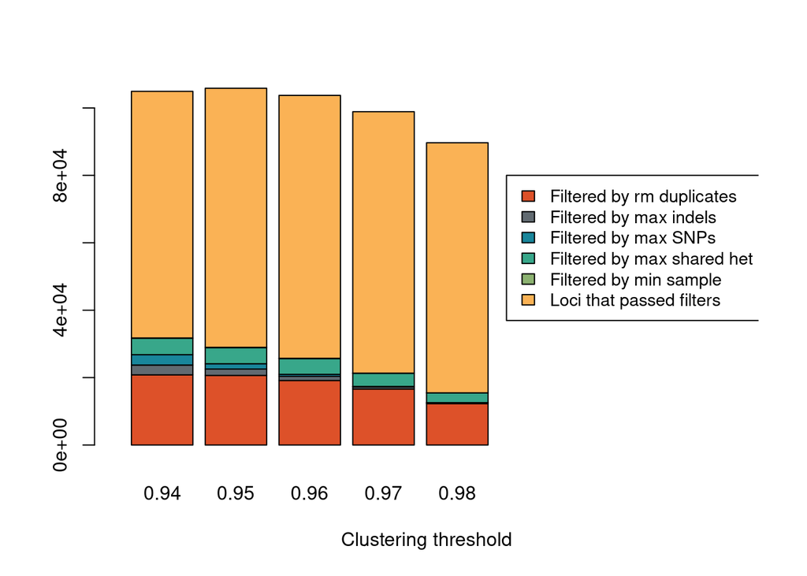

```r
paleta <- MetBrewer::met.brewer('Egypt', 6)
lociFilters <- read.table('summary_loci_filters.txt', header = TRUE)
plot(c(0, 10), c(0, 1e+05), type = 'n', xlab = 'Clustering threshold', ylab = '', axes = FALSE)
barplot(t(lociFilters[,-c(1,8)]), col = paleta, add = TRUE)
axis(1, at = (1:5) * 6 / 5 - 0.5, labels = c('0.94', '0.95', '0.96', '0.97', '0.98'), tick = FALSE)
legend(6.3, 8.0e+04, legend = c('Filtered by rm duplicates',
                                'Filtered by max indels',
                                'Filtered by max SNPs',
                                'Filtered by max shared het',
                                'Filtered by min sample',
                                'Loci that passed filters'),
       fill = paleta, cex = 0.9)
```

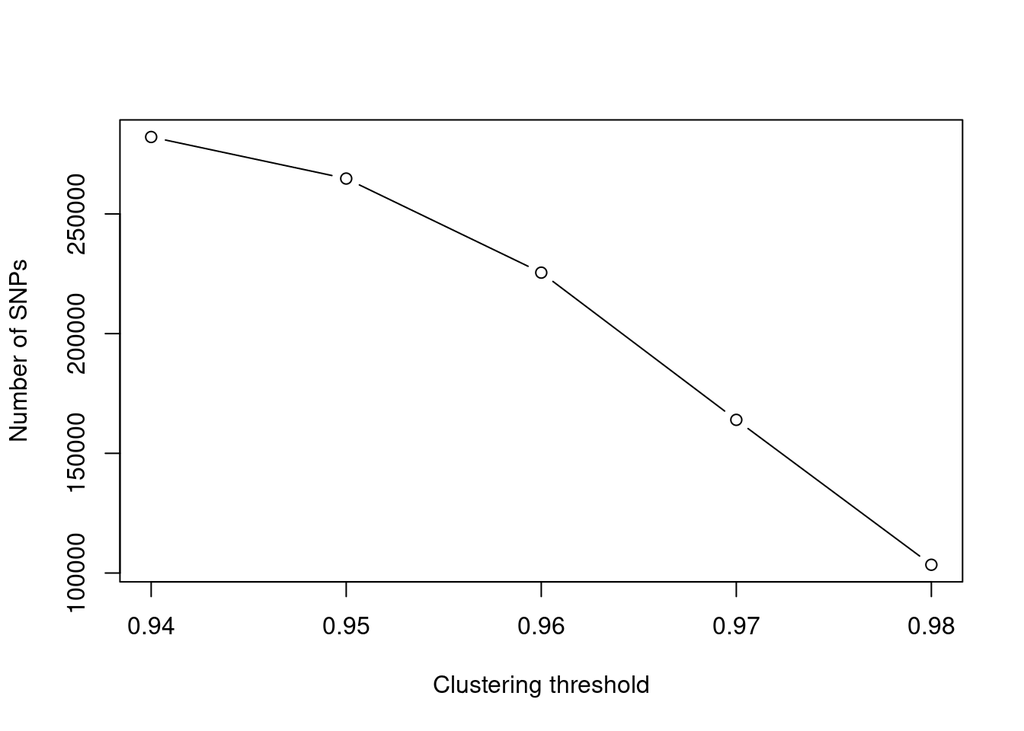

```r
plot(lociFilters$Threshold, lociFilters$NumSNPs,
     xlab = 'Clustering threshold', ylab = 'Number of SNPs', type = 'b')
```

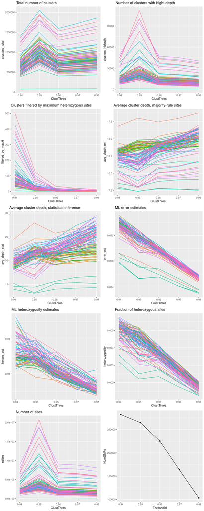

```r
library(gridExtra)
ipyradStats <- lapply(
   c(94, 95, 96, 97, 98),
   function(x) {
      s3 <- read.table(sprintf('crepi%i_clust_%.2f/s3_cluster_stats.txt', x, x/100))
      s4 <- read.table(sprintf('crepi%i_clust_%.2f/s4_joint_estimate.txt', x, x/100))
      s5 <- read.table(sprintf('crepi%i_consens/s5_consens_stats.txt', x))
      stopifnot(all.equal(row.names(s3), row.names(s4)))
      stopifnot(all.equal(row.names(s4), row.names(s5)))
      cbind(Sample = row.names(s3), s3, s4, s5[, -1], ClustThres = rep(x/100, dim(s3)[1]))
})
names(ipyradStats) <- c('94', '95', '96', '97', '98')
ipyStats <- rbind(ipyradStats[['94']], ipyradStats[['95']], ipyradStats[['96']],
                 ipyradStats[['97']], ipyradStats[['98']])
row.names(ipyStats) <- NULL
rm(ipyradStats)

p1 <- ggplot(ipyStats,
             aes(x = ClustThres, y = clusters_total, color = Sample)) +
      geom_line() + theme(legend.position = 'none') +
      ggtitle('Total number of clusters')
p2 <- ggplot(ipyStats,
             aes(x = ClustThres, y = clusters_hidepth, color = Sample)) +
      geom_line() + theme(legend.position = 'none') +
      ggtitle('Number of clusters with hight depth')
p3 <- ggplot(ipyStats,
             aes(x = ClustThres, y = filtered_by_maxH, color = Sample)) +
      geom_line() + theme(legend.position = 'none') +
      ggtitle('Clusters filtered by maximum heterozygous sites')
p4 <- ggplot(ipyStats,
             aes(x = ClustThres, y = avg_depth_mj, color = Sample)) +
      geom_line() + theme(legend.position = 'none') +
      ggtitle('Average cluster depth, majority-rule sites')
p5 <- ggplot(ipyStats,
             aes(x = ClustThres, y = avg_depth_stat, color = Sample)) +
      geom_line() + theme(legend.position = 'none') +
      ggtitle('Average cluster depth, statistical inference')
p6 <- ggplot(ipyStats,
             aes(x = ClustThres, y = error_est, color = Sample)) +
      geom_line() + theme(legend.position = 'none') +
      ggtitle('ML error estimates')
p7 <- ggplot(ipyStats,
             aes(x = ClustThres, y = hetero_est, color = Sample)) +
      geom_line() + theme(legend.position = 'none') +
      ggtitle('ML heterozygosity estimates')
p8 <- ggplot(ipyStats,
             aes(x = ClustThres, y = heterozygosity, color = Sample)) +
      geom_line() + theme(legend.position = 'none') +
      ggtitle('Fraction of heterozygous sites')
p9 <- ggplot(ipyStats,
             aes(x = ClustThres, y = nsites, color = Sample)) +
      geom_line() + theme(legend.position = 'none') +
      ggtitle('Number of sites')
pF <- ggplot(lociFilters, aes(x = Threshold, y = NumSNPs)) +
   geom_line() + geom_point()
grid.arrange(p1, p2, p3, p4, p5, p6, p7, p8, p9, pF, ncol = 2)
```

## Conclusions

The total number of clusters increase as clustering threshold increases, because some clusters get split when requiring a higher clustering threshold. However, the number of clusters filtered because of having too many heterozygous sites drops between clustering thresholds 0.94 and 0.95, and remains low from then on. The 0.95 threshold also generates some of the highest numbers of sites and SNPs (McCartney-Melstad, Gidiş, and Shaffer 2019).

I will use results from clustering threshold 0.95.

# References

McCartney-Melstad, E., M. Gidiş, and H. B. Shaffer. 2019. “An Empirical Pipeline for Choosing the Optimal Clustering Threshold in RADseq Studies.” *Molecular Ecology Resources* 19 (5): 1195–1204. https://doi.org/10.1111/1755-0998.13029.